# IODS final course project

Demographic and Health Factors Affecting Population Growth.

### Prepared by: Yuliya Skakun.

### 06.03.2017

> e-mail: yuliya.skakun@helsinki.fi

*[My GitHub Repository](https://github.com/YuliyaSkakun/IODS-final)*

*[My Course Diary](https://yuliyaskakun.github.io/IODS-final/)*

## Abstract

I have decided to perform the OLS methodology as it is the one that will help to determine which of the variables are the best in the explanation of the fluctuations in my dependent variable – population growth.

The results of my regression analysis have been modified in order to be able to better capture the effect of the independent variables on the population growth.

Therefore, my main conclusion is that **fertility, wage rate, sanitation facilities** are the ones that **positively** affect the population growth while **unemployment, survival65 and tuberculosis** have a **negative** effect.

All of the results are in line with my intuition except for the tuberculosis successful treatment rate that was initially thought to be positive.

## Introduction

Population growth is highly associated with the economic development and the migrant inflow to the country. However, such factors as health development and demographic structure may sometimes be even more significant in their force than economic development as health of the nation may predetermine the economic growth. Report on the Commission on Macroeconomics and Health (CMH, 2001) states that health plays an important role in the population growth and the economic development because of the correlation between the level of income and the burden of illness. As the result of the higher economic growth there are more possibilities on implementing programs for improving the health and increase population growth. These proves the interconnections between each other and it is becoming obvious that the issue of the health development is of high importance. However, it is influencing the welfare and the economic development through the population growth.

The aim of the research is to check for the possible demographic and health factors which may influence the population growth. In the case of the demographic factor I will include the fertility rate which is one of the factors affecting population growth directly. The study by Joshi and Schultz (2007) have shown that usually all the population increase programs are voluntary and they are aiming at the increase of the fertility which is a demographic side of population growth issue. The results of their study has also shown that in the case rate of the fertility increase, the welfare of families, on average, increases as well. From that I may conclude that fertility and the population growth have one of the strongest impact on the welfare of the society which is an ultimate goal of every nation. However, it is quite difficult to evaluate the effect of the fertility rate increase in the country (Moffit, 2005).

Another factor which will be tested in the research is health which can affect population growth through different mechanisms (Bloom and Cannin, 2008). The first one is through higher saving rates because the healthier the person the less he or she has to spend on the curing different illnesses and the more disposable income the person posses and as a result, ability to have children. Another mechanism is through education as in the case of good childhood health, they skip school less and increase their cognitive abilities together with a human capital in the country which affects economic and population growth. Also, The Mexican Commission on Macroeconomics and Health (2004) states that health development should be treated as an asset in which every country has to invest as it will minimize the number of sick people and avoid increases in unemployment rates, mortality rates and as a result decrease in GDP.

All in all, I will try to search for the factors of the population growth through health and demographic factors.

## Model Specification

As the aim of the research is to find the demographic and health factors which may affect the population, I will be dealing with a cross section data and analyze the effects for high income countries. The data is taken form the World Bank Databank for the year of 2013. The main regression equation is presented down below:

*Pop= β0 + β1agedep + β2limmuni + β3sanit + β4sqwage + β5wage + β6tuberculosis + β7fertility + β8survival65 + β9unemp + β10lunemp*

The dependent variable of my choice Pop is growth rate of mid-year population for the year of 2013 which is measured in percents. The population includes all residents of a country independently from their citizenship, but excludes refugees, asylum-seekers.

The first independent variable – **agedep**, represents the age dependency ratio of people of ages older than 15 and younger than 64 (expressed as a proportion per 100 working-age population). I expect the variable to have a positive effect on the population growth as people of these ages are more likely to have children. Nevertheless, it may have a very strong effect on the dependent variable as both of them account for similar indices.

The next explanatory variable – **limmuni**, the data for adequate immunization of children who received vaccines against diphtheria, pertussis (whooping cough), and tetanus (DPT). I’ve implemented the log function as I’ve wanted to normalize the data and present better interpretation of regression results. I anticipate the variable to have a positive sign after the regression, as those diseases are extremely dangerous for children at young age; hence, if the condition of vaccination isn’t met, population growth may be lower. Despite that, as I perform the regression on the data for high-income countries, the variable should not have a strong effect as the level of income often goes along with the development of medical system in a country.

Percentage of the population who uses improved sanitation facilities **sanit** (flush/pour flush, composting toilet, etc.) is next independent variable. I expect it not to have as high impact as on the low-income countries because it follows a similar logic to the variable limmuni: high-income countries are perceived a priori as having good sanitation facilities. That’s why I expect the sign of the regressed variable to be positive, but the degree of impact – to be low.

I also include the variable **tuberculosis** that stands for the successful treatment of tuberculosis as a percentage of all new tuberculosis cases. The “success” is defined when a patient completed treatment in a tuberculosis control program. The variable is expected to have positive effect on the population growth, as it prevents the disease and lowers mortality.

The seventh explanatory variable **fertility** represents the fertility rate, i.e. how many children a woman could have gave birth to. As it is one of the major drivers of the population growth, hence the impact is predicted to be strong and positive.

I also consider **survival65** - variable survival rates to age 65 of a cohort of newborn infants when subject to current age-specific mortality rates. The variable is expected to have positive influence on the population growth as higher survival rates give larger time span to have more children. Nevertheless, in the high income-countries the effect probably won’t be of the same significance as in the low-income ones.

Additionally, I include 2 variables **unemp**,**lunemp** that deal with unemployment of females (percentage of female labour force) and long-term unemployment of both genders as a percentage of total unemployment in a country. As for females I would expect the effect to be positive: if a female is unemployed over time, but is married, for example, she may consider having children. In case of long-term unemployment impact on the population growth – the effect is expected to be negative as well: unemployment assumes low or even absent wages, as children require a lot of investment, it may be simply not feasible for people to have more children when experiencing unemployment.

```r
setwd("/Users/skakunyuliya/IODS-final/IODS-final")
data <- read.csv(file='MOOC.csv', header=TRUE, row.names=1, sep=",")
agedep <- data$agedep
fertility <- data$fertility
imuni <- data$imuni
sanit <- data$sanit
survival65 <- data$survival65
pop <- data$pop
tuberculosis <- data$tuberculosis
wage <- data$wage
unemp <- data$unemp

dim(data)
```

```
## [1] 79 10
```

```r
str(data)
```

```
## 'data.frame':    79 obs. of  10 variables:
##  $ country     : Factor w/ 79 levels "Andorra","Antigua and Barbuda",..: 1 2 3 4 5 6 7 8 9 10 ...
##  $ agedep      : num  NA 47.2 56.7 44.4 49.6 ...
##  $ fertility   : num  NA 2.09 2.33 1.67 1.92 ...
##  $ imuni       : int  95 98 94 NA 94 76 92 99 87 96 ...
##  $ sanit       : num  100 NA 95.8 97.7 100 100 92 99.2 95.5 99.5 ...
##  $ survival65  : num  NA 7.12 10.7 11.33 14.38 ...
##  $ pop         : num  -4.4 1.023 1.047 0.514 1.734 ...
##  $ tuberculosis: int  60 67 51 NA 85 72 76 NA 100 79 ...
##  $ wage        : num  NA NA 75.3 NA 89.6 ...
##  $ unemp       : num  NA NA 8.6 NA 5.6 ...
```

```r
colnames(data)
```

```
##  [1] "country"      "agedep"       "fertility"    "imuni"
##  [5] "sanit"        "survival65"   "pop"          "tuberculosis"
##  [9] "wage"         "unemp"
```

The numerical data was downloaded from the World Bank. It is a cross section data for 2013 that have **10 variables** to be discussed later. No data wrangling have been done.

Data contains **79 observations** (countries) that are listed below

| Countries |  |  |
| --- | --- | --- |
| Andorra | Croatia | Hungary |
| Antigua and Barbuda | Curacao | Iceland |
| Argentina | Cyprus | Ireland |
| Aruba | Czech Republic | Isle of Man |
| Australia | Denmark | Israel |
| Austria | Equatorial Guinea | Italy |
| Bahamas, The | Estonia | Japan |
| Bahrain | Faeroe Islands | Korea, Rep. Barbados |
| Belgium | France | Latvia |
| Bermuda | French Polynesia | Liechtenstein |
| Brunei Darussalam | Germany | Lithuania |
| Canada | Greece | Luxembourg |
| Cayman Islands | Greenland Macao | SAR, China |
| Channel Islands | Guam | Malta |
| Chile | Hong Kong SAR, China | Monaco |
| Netherlands | New Caledonia | Portugal |
| Saudi Arabia | New Zealand | Puerto Rico |
| Seychelles | Northern Mariana Islands | Qatar |
| Singapore | Norway | Russian Federation |
| Sint Maarten (Dutch part) | Oman | San Marino |
| Slovak Republic | Poland | United Arab Emirates |
| Slovenia | St. Martin (French part) | United Kingdom |
| Spain | Sweden | United States |
| St. Kitts and Nevis | Switzerland | Uruguay |
| Venezuela, RB | Trinidad and Tobago | Virgin Islands (U.S.) |
| Turks and Caicos Islands |  |  |

```r
data <- read.csv(file='MOOC.csv', header=TRUE, row.names=1, sep=",")
summary(data)
```

```
##                 country       agedep        fertility         imuni
##  Andorra            : 1   Min.   :17.18   Min.   :1.124   Min.   :42.00
##  Antigua and Barbuda: 1   1st Qu.:42.40   1st Qu.:1.454   1st Qu.:92.00
##  Argentina          : 1   Median :48.99   Median :1.772   Median :95.00
##  Aruba              : 1   Mean   :47.10   Mean   :1.823   Mean   :93.36
##  Australia          : 1   3rd Qu.:52.34   3rd Qu.:2.016   3rd Qu.:98.00
##  Austria            : 1   Max.   :73.80   Max.   :4.924   Max.   :99.00
##  (Other)            :73   NA's   :14      NA's   :11      NA's   :20
##      sanit          survival65           pop           tuberculosis
##  Min.   : 72.20   Min.   : 0.9419   Min.   :-4.3997   Min.   :  0.00
##  1st Qu.: 96.60   1st Qu.: 9.8954   1st Qu.: 0.2605   1st Qu.: 62.00
##  Median : 98.80   Median :14.0171   Median : 0.7566   Median : 77.00
##  Mean   : 96.76   Mean   :13.1440   Mean   : 0.8975   Mean   : 72.92
##  3rd Qu.: 99.90   3rd Qu.:17.7501   3rd Qu.: 1.2076   3rd Qu.: 84.00
##  Max.   :100.00   Max.   :25.0093   Max.   : 9.7155   Max.   :100.00
##  NA's   :16       NA's   :14                          NA's   :18
##       wage           unemp
##  Min.   :59.20   Min.   : 1.600
##  1st Qu.:82.33   1st Qu.: 5.175
##  Median :86.35   Median : 7.400
##  Mean   :84.95   Mean   : 8.984
##  3rd Qu.:89.67   3rd Qu.:11.125
##  Max.   :99.30   Max.   :31.300
##  NA's   :31      NA's   :23
```

As I have chosen to analyse only the high income countries, there is observed not a huge volatility of the data. That will be helpfull when doing empirical analysis as the may be of normal distribution

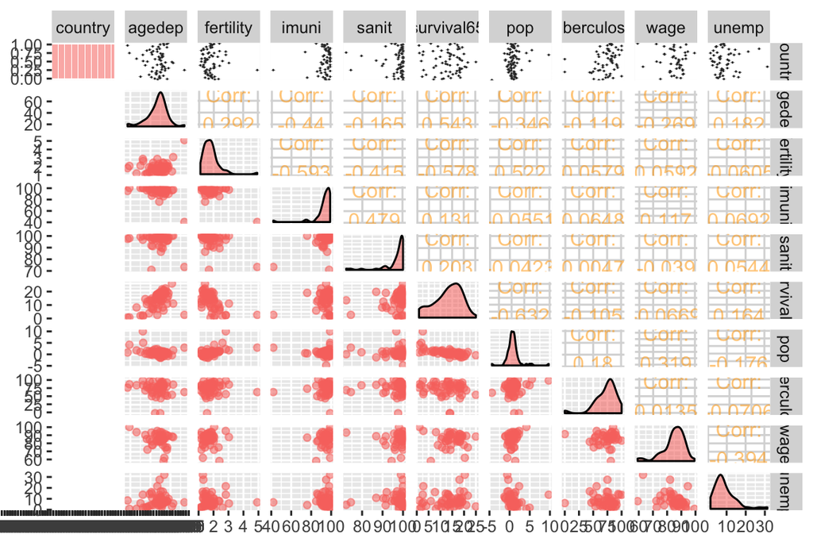

```r
data <- read.csv(file='MOOC.csv', header=TRUE, row.names=1, sep=",")
agedep <- data$agedep
fertility <- data$fertility
imuni <- data$imuni
sanit <- data$sanit
survival65 <- data$survival65
pop <- data$pop
tuberculosis <- data$tuberculosis
wage <- data$wage
unemp <- data$unemp

library(GGally)
library(ggplot2)

pic <- ggpairs(data, mapping = aes( alpha = 0.3, col="orange"), cardinality_threshold=79, lower = list(combo = wrap("facethist", bins = 20)))


pic
```

Some of the variables’ distribution (imuni, unemp) is skewed. Later on, in the process of the empirical analysis, imuni and unemp will be thansformed into the log scale in order to normalize those. Every variables distribution is centered throughout countries. Therefore, I assume there will not be oserved a lot of outliers in the data. However, I will draw the boxplot in order to be sure.

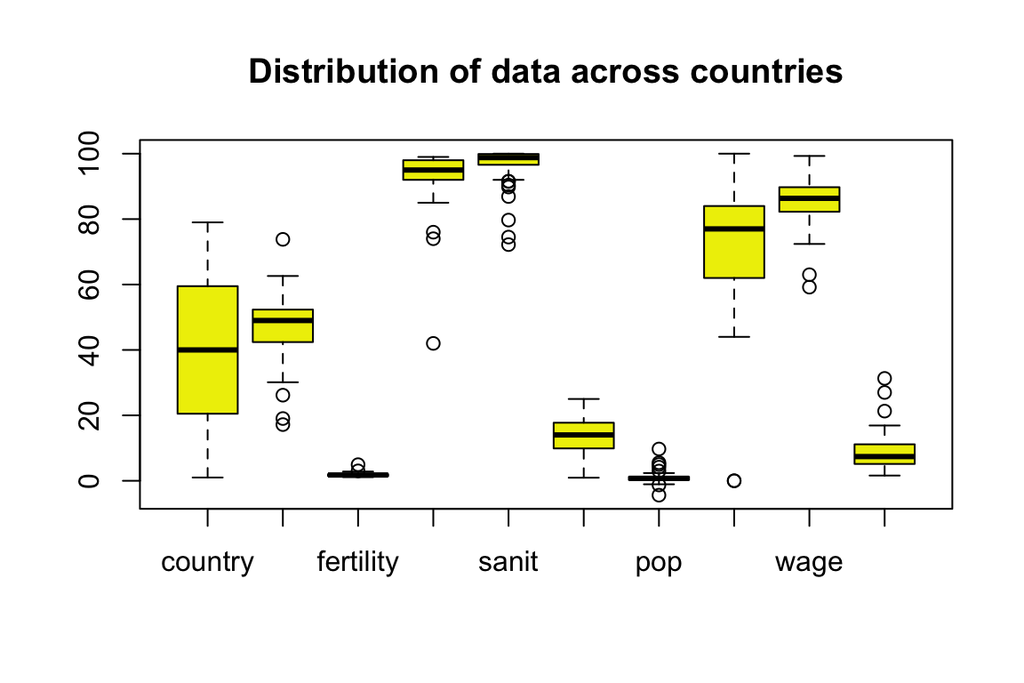

```r
data <- read.csv(file='MOOC.csv', header=TRUE, row.names=1, sep=",")
boxplot(data, main="Distribution of data across countries", col = "yellow2")
```

There are some outliers. However, I do believe that the elimination of those would lead to the small number of observations and bad prediction power.

Now I will draw couple of the distribution graphs (histograms) in order to anlayse separate variables in details.

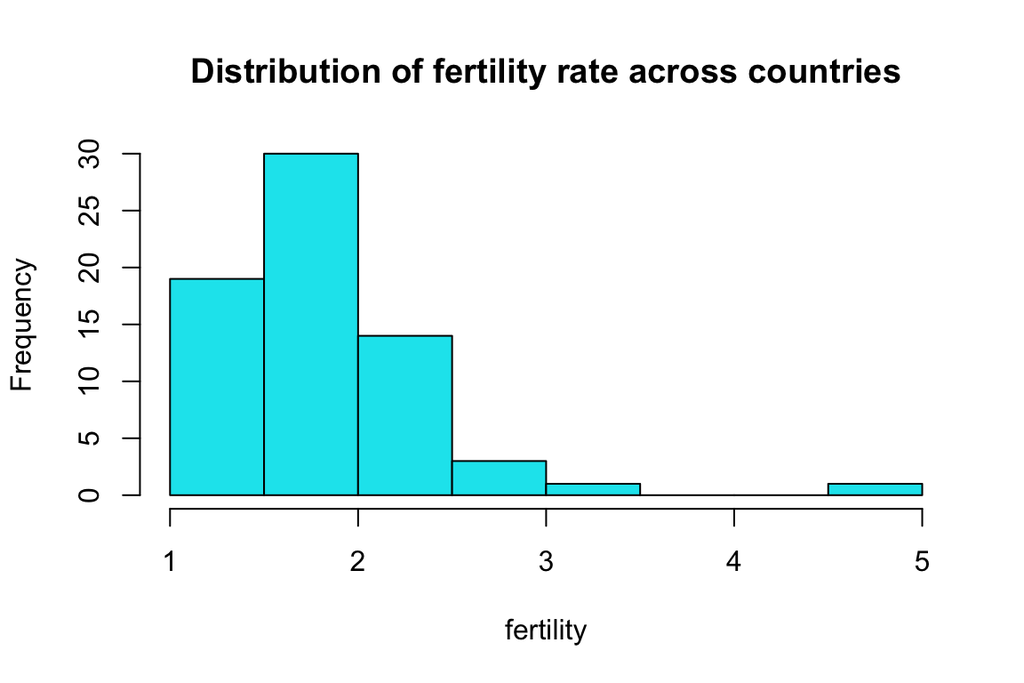

```r
data <- read.csv(file='MOOC.csv', header=TRUE, row.names=1, sep=",")

hist(data$fertility, main="Distribution of fertility rate across countries", xlab="fertility", col = "turquoise2")
```

Histogram on the fertility shows than on everage in high income countries, women tend to give a birth to 1-2 children. However, the cases of having 3 and 5 are also seen. These can be outliers in the distribution

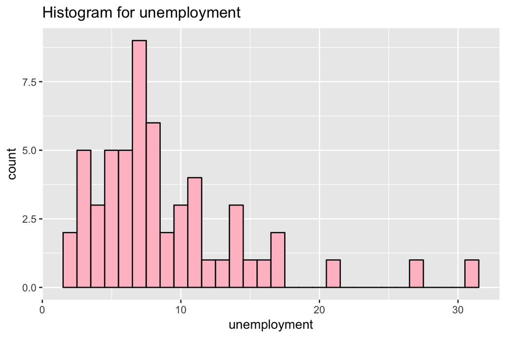

```r
data <- read.csv(file='MOOC.csv', header=TRUE, row.names=1, sep=",")
qplot(data$unemp, geom = "histogram", binwidth = 1, main = "Histogram for unemployment", xlab = "unemployment", col = I("black"), fill = I("pink"))
```

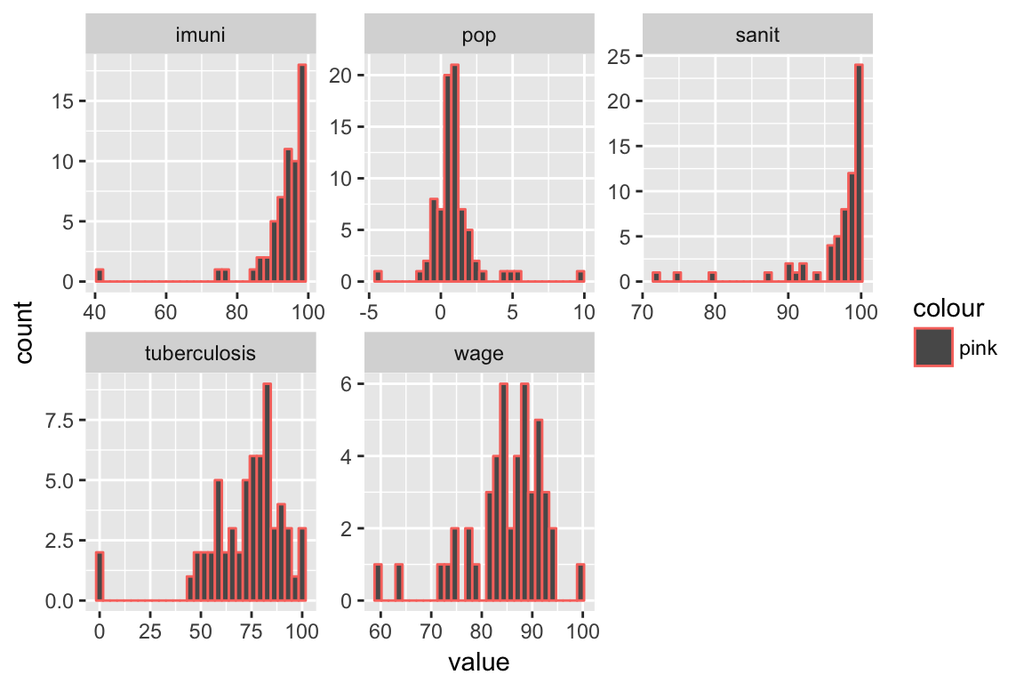

```r
data <- read.csv(file='MOOC.csv', header=TRUE, row.names=1, sep=",")
library(dplyr)
library(tidyr)
agedep <- data$agedep
fertility <- data$fertility
imuni <- data$imuni
sanit <- data$sanit
survival65 <- data$survival65
pop <- data$pop
tuberculosis <- data$tuberculosis
wage <- data$wage
unemp <- data$unemp
join= c("imuni","wage", "tuberculosis","pop", "sanit")
data8 <-select(data, one_of(join))

gather(data8) %>% ggplot(aes(value, col="pink")) + facet_wrap("key", scales = "free") + geom_histogram()
```

There is obsereved an extremely high level of immunization and availability of the sanitation facilities in high income countries, on average almost 0 population growth. There is also oberved high tuberculosis treatment success rate and wages

I will also would like to look at the distribution of data from the perspective of the applicability of least squares method and the correlation between variables.

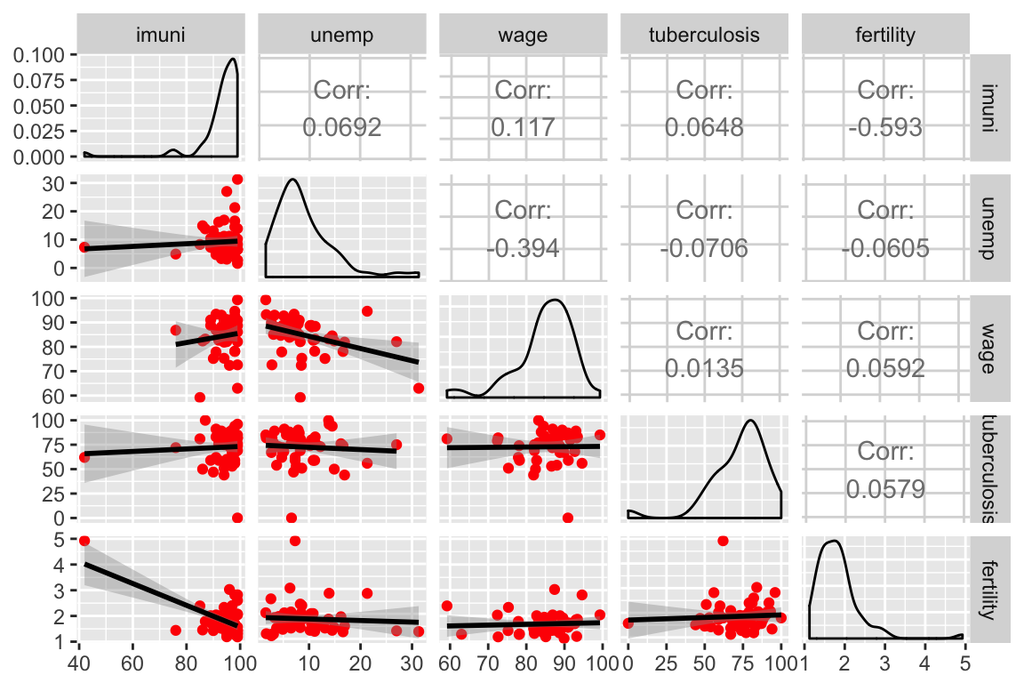

```r
library(dplyr)
data <- read.csv(file='MOOC.csv', header=TRUE, row.names=1, sep=",")
join= c("imuni","unemp","wage", "tuberculosis","fertility")
data2 <-select(data, one_of(join))

graph1 = ggpairs(data2, lower = list(continuous = wrap("smooth", method = "lm", color="red")))
graph1
```

As the data is centered, majority of the regression line are straight except for those where the huge outliers are visible

As the variable country and sanit were not used in the assesment of the regression lines I will build couple of more graphs in order to make sure that they look the same as previously analysed

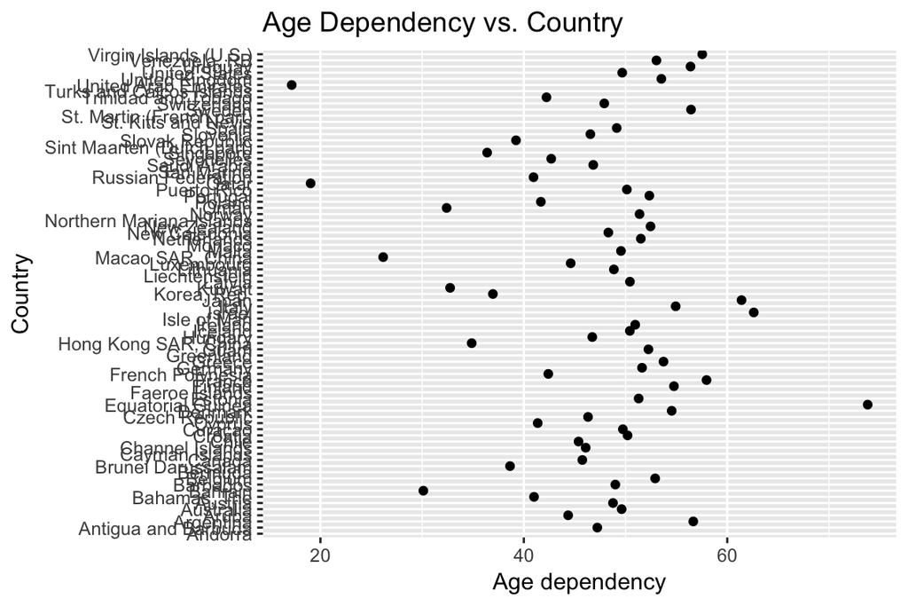

```r
data <- read.csv(file='MOOC.csv', header=TRUE, row.names=1, sep=",")
agedep <- data$agedep
fertility <- data$fertility
imuni <- data$imuni
sanit <- data$sanit
survival65 <- data$survival65
pop <- data$pop
tuberculosis <- data$tuberculosis
wage <- data$wage
unemp <- data$unemp

qplot(agedep, country, data = data) + xlab("Age dependency") + ylab("Country") + ggtitle("Age Dependency vs. Country") + geom_smooth(method = "lm")
```

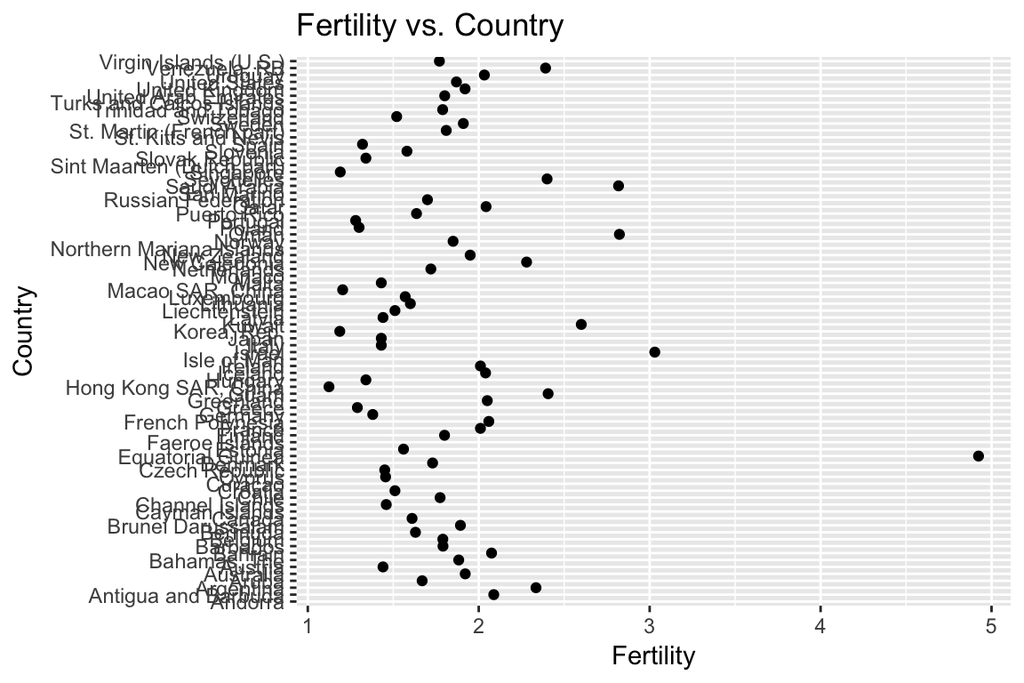

```r
data <- read.csv(file='MOOC.csv', header=TRUE, row.names=1, sep=",")
agedep <- data$agedep
fertility <- data$fertility
imuni <- data$imuni
sanit <- data$sanit
survival65 <- data$survival65
pop <- data$pop
tuberculosis <- data$tuberculosis
wage <- data$wage
unemp <- data$unemp

qplot(fertility, country, data = data) + xlab("Fertility") + ylab("Country") + ggtitle("Fertility vs. Country") + geom_smooth(method = "lm", cl="yellow")
```

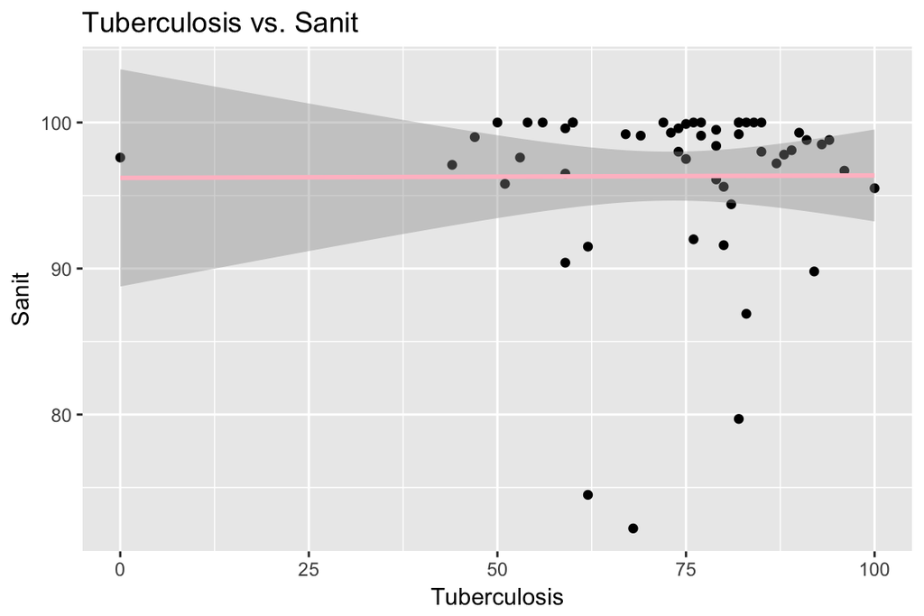

```r
data <- read.csv(file='MOOC.csv', header=TRUE, row.names=1, sep=",")
agedep <- data$agedep
fertility <- data$fertility
imuni <- data$imuni
sanit <- data$sanit
survival65 <- data$survival65
pop <- data$pop
tuberculosis <- data$tuberculosis
wage <- data$wage
unemp <- data$unemp

qplot(tuberculosis, sanit, data = data) + xlab("Tuberculosis") + ylab("Sanit") + ggtitle("Tuberculosis vs. Sanit") + geom_smooth(method = "lm", col="pink")
```

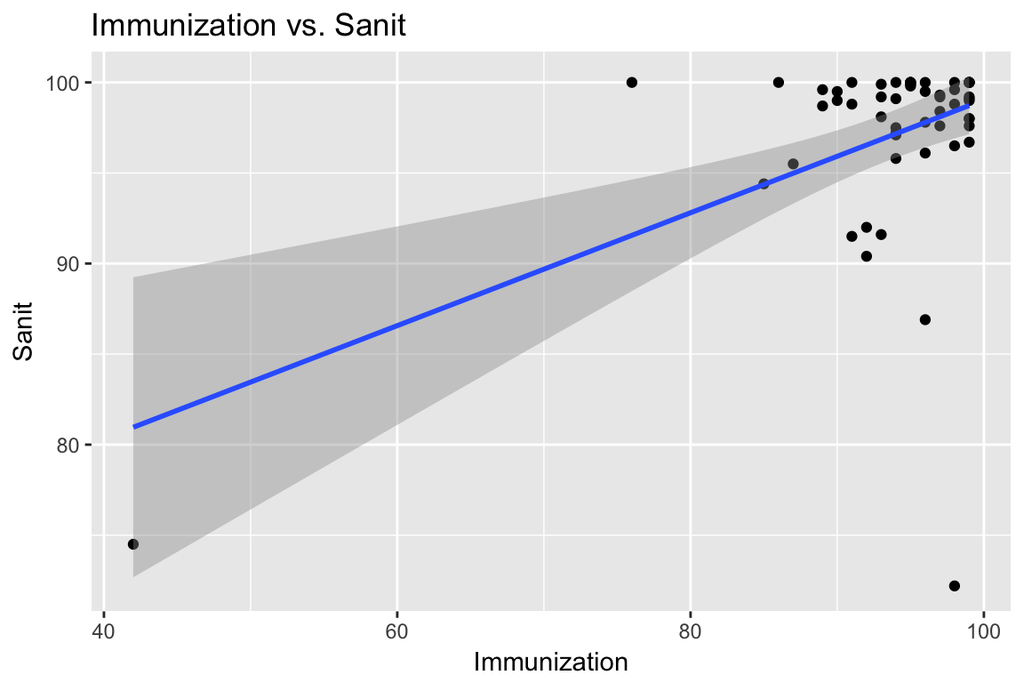

```r
data <- read.csv(file='MOOC.csv', header=TRUE, row.names=1, sep=",")
agedep <- data$agedep
fertility <- data$fertility
imuni <- data$imuni
sanit <- data$sanit
survival65 <- data$survival65
pop <- data$pop
tuberculosis <- data$tuberculosis
wage <- data$wage
unemp <- data$unemp

qplot(imuni, sanit, data = data) + xlab("Immunization") + ylab("Sanit") + ggtitle("Immunization vs. Sanit") + geom_smooth(method = "lm")
```

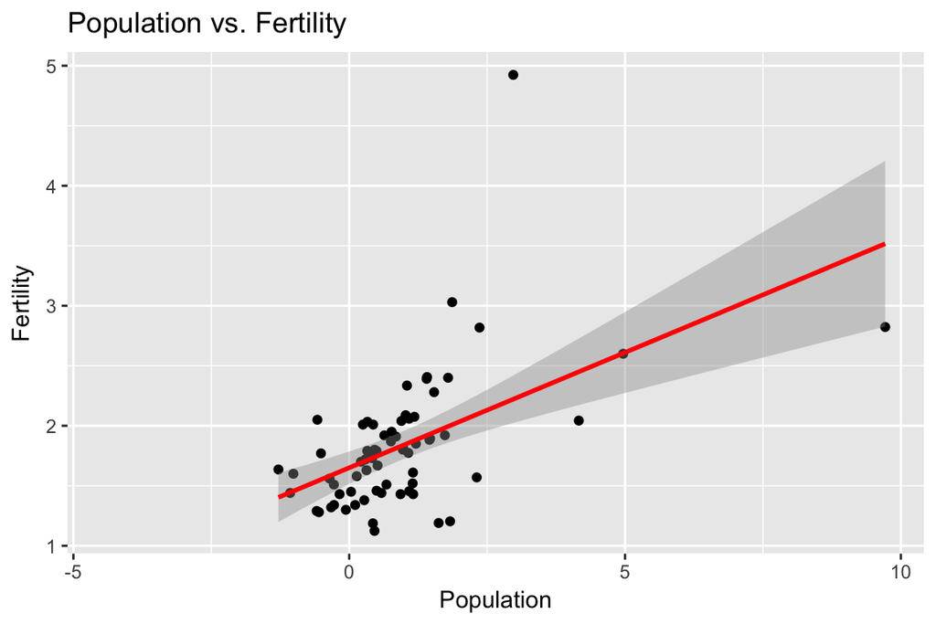

```r
data <- read.csv(file='MOOC.csv', header=TRUE, row.names=1, sep=",")
agedep <- data$agedep
fertility <- data$fertility
imuni <- data$imuni
sanit <- data$sanit
survival65 <- data$survival65
pop <- data$pop
tuberculosis <- data$tuberculosis
wage <- data$wage
unemp <- data$unemp

qplot(pop,fertility, data = data) + xlab("Population") + ylab("Fertility") + ggtitle("Population vs. Fertility") + geom_smooth(method = "lm", col="red")
```

Yes, the performed graphs are showing the same patter of the regression lines

Now, I will build the Correlation matrix of independent variables in order to be able to better see the correlations

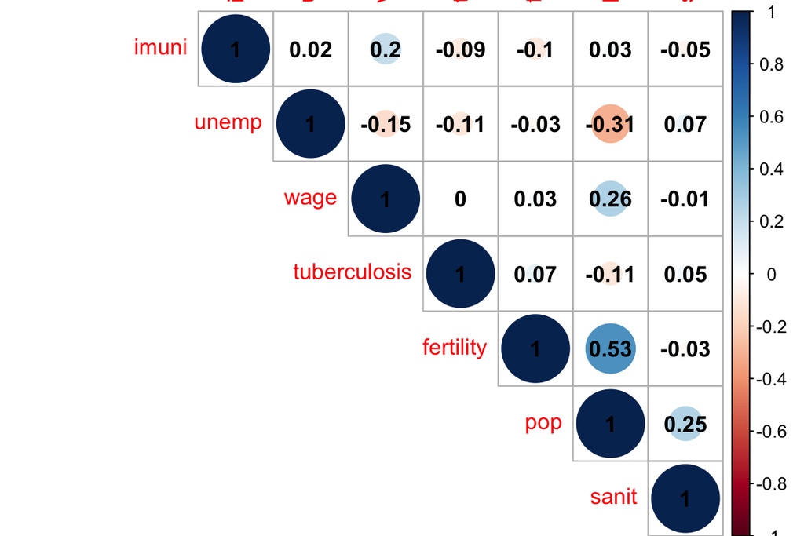

```r
library(corrplot)
library(dplyr)

data <- read.csv(file='MOOC.csv', header=TRUE, row.names=1, sep=",")
join= c("imuni","unemp","wage", "tuberculosis","fertility", "pop","sanit")
data4 <-select(data, one_of(join))
data5 <- data4[complete.cases(data4), ]
cor_matrix<-cor(data5) %>% round(digits=2)

library(dygraphs)
corrplot(cor_matrix, method = "circle", tl.cex = 1, addCoef.col = "black", type="upper")
```

Correlation matrix shows that the strongest positive correlation is between fertility and population growth that is logical to observe. The rest of the variables show marginal correlation coeeficient. This can be because of the fact that both demographical and health factors that are not directly correlated are analysed. Population and sanit show positive correlation.

Interesting to note is that the level of unemployment and population growth are negatively correlated (-0.31), whereas population and wage are positively (0.26).

## Model Estmation Results

Now, I will perform the ordinary least squares regression analysis in order to analyse the factors affecting population growth. I will be using OLS estimation method in order to make sure that the sum of squared errror between the dependent and independ variables are minimized. In such way the estimation results are the most acurate.

Those variable that will show some explanatory power will be significant.Therefore, I will be able to analyse and draw conclsions on the variables that can the most accurately explain the population growth.

```r
data <- read.csv(file='MOOC.csv', header=TRUE, row.names=1, sep=",")
agedep <- data$agedep
fertility <- data$fertility
imuni <- data$imuni
sanit <- data$sanit
survival65 <- data$survival65
pop <- data$pop
tuberculosis <- data$tuberculosis
wage <- data$wage
unemp <- data$unemp

limmuni <- log(imuni)
lunemp <- log(unemp)
sqwage <- sqrt(wage)
data1=cbind(data,limmuni,lunemp,sqwage)



model <- lm(pop ~ agedep+limmuni+sanit+sqwage+wage+tuberculosis+fertility+survival65+unemp+lunemp, data = data1)
summary(model)
```

```
##
## Call:
## lm(formula = pop ~ agedep + limmuni + sanit + sqwage + wage +
##     tuberculosis + fertility + survival65 + unemp + lunemp, data = data1)
##
## Residuals:
##      Min       1Q   Median       3Q      Max
## -0.69749 -0.21539  0.00483  0.17197  0.63240
##
## Coefficients:
##               Estimate Std. Error t value Pr(>|t|)
## (Intercept)  23.684384  20.823519   1.137  0.26502
## agedep       -0.031070   0.031758  -0.978  0.33629
## limmuni       0.005666   1.266753   0.004  0.99646
## sanit         0.066475   0.013253   5.016 2.66e-05 ***
## sqwage       -6.429617   4.696370  -1.369  0.18186
## wage          0.381801   0.263302   1.450  0.15816
## tuberculosis -0.011944   0.003628  -3.292  0.00269 **
## fertility     0.969611   0.570459   1.700  0.10027
## survival65   -0.064498   0.056212  -1.147  0.26093
## unemp         0.009822   0.039603   0.248  0.80595
## lunemp       -0.595506   0.382179  -1.558  0.13042
## ---
## Signif. codes:  0 '***' 0.001 '**' 0.01 '*' 0.05 '.' 0.1 ' ' 1
##
## Residual standard error: 0.3881 on 28 degrees of freedom
##   (40 observations deleted due to missingness)
## Multiple R-squared:  0.886,  Adjusted R-squared:  0.8453
## F-statistic: 21.76 on 10 and 28 DF,  p-value: 1.225e-10
```

The first regression I will running is based on the cross-sectional data for 79 high income countries (as defined by the World Bank Dataset from which I’ve retrieved the data)

One of the reasons for that many problems is the lack of the data. Not all of the high income countries have data for all of the chosen variables in this specific year; hence, instead of analyzing suggested 79 countries, only 39 are available for testing.

I will also draw some of the plots in order to test for the validity of the model

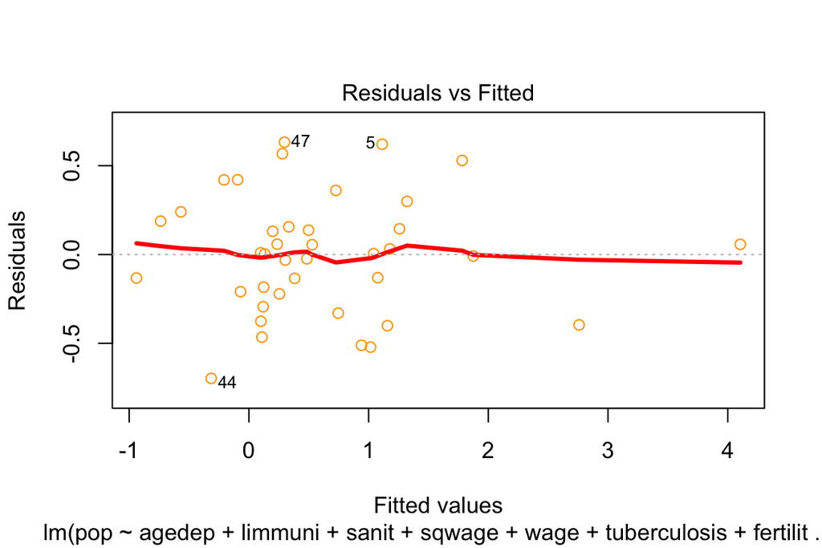

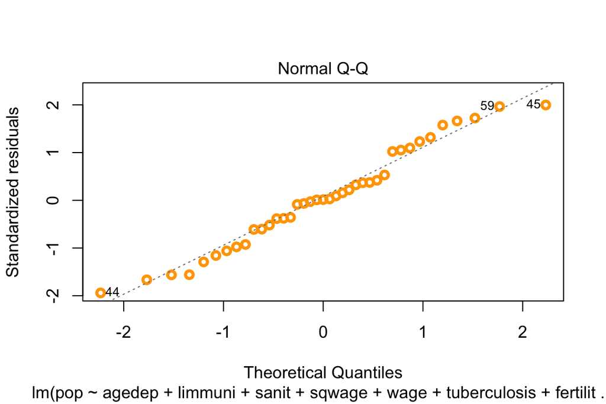

```r
data <- read.csv(file='MOOC.csv', header=TRUE, row.names=1, sep=",")
agedep <- data$agedep
fertility <- data$fertility
imuni <- data$imuni
sanit <- data$sanit
survival65 <- data$survival65
pop <- data$pop
tuberculosis <- data$tuberculosis
wage <- data$wage
unemp <- data$unemp

limmuni <- log(imuni)
lunemp <- log(unemp)
sqwage <- sqrt(wage)
data1=cbind(data,limmuni,lunemp,sqwage)

model <- lm(pop ~ agedep+limmuni+sanit+sqwage+wage+tuberculosis+fertility+survival65+unemp+lunemp, data = data1)
plot(model, which = c(1, 2), col = "orange",  lwd = 3)
```

The plots on the residual does not show much of being fitted that is proving the fact that the model should be respecified.

The normality plot is on average pointing to the fact that the data is normaly distributed

## Model Respicification

The new model we are going to test for high-income countries is

**Pop= β0 + β1tuberculosis + β2limmuni + β3sanit + β4sqwage + β5fertility + β6survival65 + β7unemp**

```r
data <- read.csv(file='MOOC.csv', header=TRUE, row.names=1, sep=",")
agedep <- data$agedep
fertility <- data$fertility
imuni <- data$imuni
sanit <- data$sanit
survival65 <- data$survival65
pop <- data$pop
tuberculosis <- data$tuberculosis
wage <- data$wage
unemp <- data$unemp

limmuni <- log(imuni)
lunemp <- log(unemp)
sqwage <- sqrt(wage)
data1=cbind(data,limmuni,lunemp,sqwage)


model2 <- lm(pop ~ tuberculosis+limmuni+sanit+sqwage+fertility+survival65+unemp, data = data1)
summary(model2)
```

```
##
## Call:
## lm(formula = pop ~ tuberculosis + limmuni + sanit + sqwage +
##     fertility + survival65 + unemp, data = data1)
##
## Residuals:
##     Min      1Q  Median      3Q     Max
## -0.7036 -0.3074  0.0338  0.2168  0.6182
##
## Coefficients:
##                Estimate Std. Error t value Pr(>|t|)
## (Intercept)  -10.506848   6.122908  -1.716 0.096143 .
## tuberculosis  -0.010125   0.003772  -2.684 0.011558 *
## limmuni        0.274104   1.316541   0.208 0.836435
## sanit          0.068357   0.013390   5.105 1.59e-05 ***
## sqwage         0.655098   0.174614   3.752 0.000725 ***
## fertility      0.349643   0.200234   1.746 0.090685 .
## survival65    -0.145557   0.017246  -8.440 1.56e-09 ***
## unemp         -0.056331   0.013220  -4.261 0.000176 ***
## ---
## Signif. codes:  0 '***' 0.001 '**' 0.01 '*' 0.05 '.' 0.1 ' ' 1
##
## Residual standard error: 0.4156 on 31 degrees of freedom
##   (40 observations deleted due to missingness)
## Multiple R-squared:  0.8552, Adjusted R-squared:  0.8225
## F-statistic: 26.16 on 7 and 31 DF,  p-value: 2.524e-11
```

The log of immunization limmuni variable turned out to be insignificant but positive in its sign. This result is actually fulfills my expectations, as higher rates of immunization help to prevent deaths from certain diseases; but, as I’ve mentioned, in high income countries the scope of the impact is relatively low.

The sqwage variable is significant at 1% significance level and the effect is positive that was confirmed by the correlation matrix results as well.

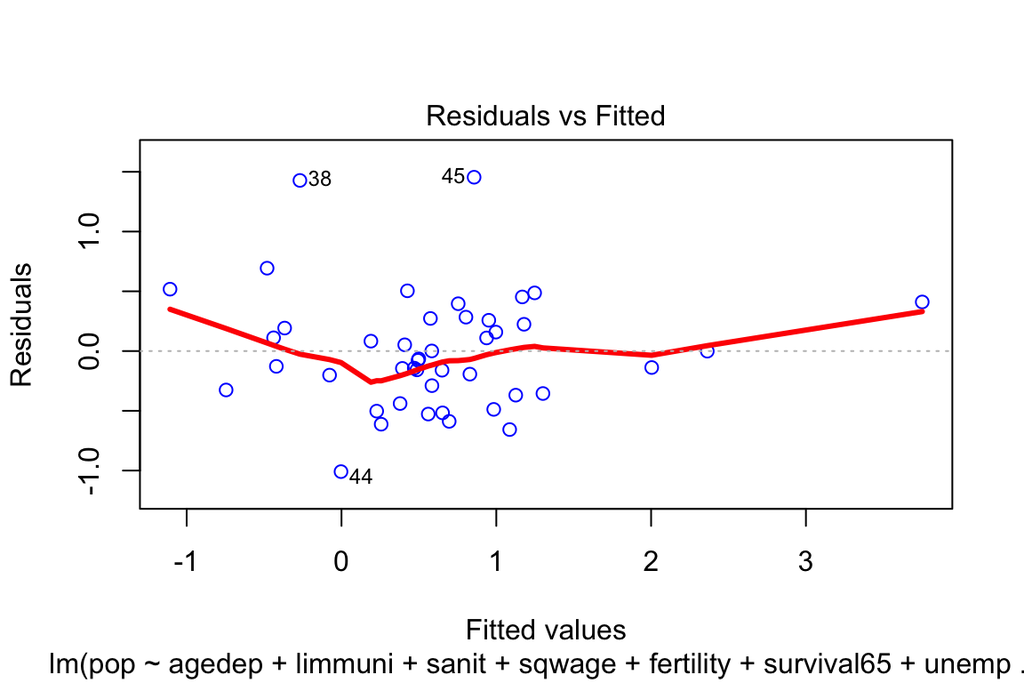

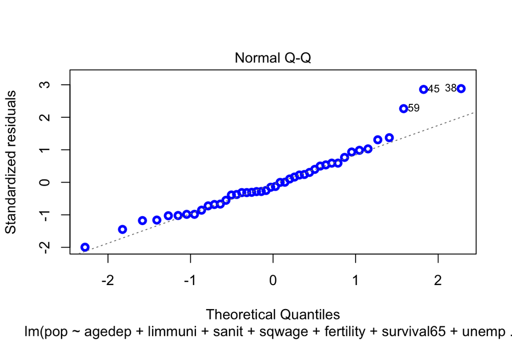

```r
data <- read.csv(file='MOOC.csv', header=TRUE, row.names=1, sep=",")
agedep <- data$agedep
fertility <- data$fertility
imuni <- data$imuni
sanit <- data$sanit
survival65 <- data$survival65
pop <- data$pop
tuberculosis <- data$tuberculosis
wage <- data$wage
unemp <- data$unemp

limmuni <- log(imuni)
lunemp <- log(unemp)
sqwage <- sqrt(wage)
data1=cbind(data,limmuni,lunemp,sqwage)


model2 <- lm(pop ~ agedep+limmuni+sanit+sqwage+fertility+survival65+unemp, data = data1)
plot(model2, which = c(1, 2), col = "blue",  lwd = 3)
```

Data follows the normal distribution in this case as well

## Conclusion

I’ve also found out that some variables are need to be substituted by proxies due to the lack of data, or even eliminated from the model, as their significance varies in high- and low-income countries. If improvements as better quality of data or larger number of observations have been made, the models may be useful in order to observe patterns in demographic changes conditional on changes in health system and macroeconomic indicators.

## Bibliography

*1. The Mexican Commission on Macroeconomics and Health, the development of health (2004) ‘Investing In Health For Economic Development’. The Mexican Commission on Macroeconomics and Health, the development of health*

*2. Bloom D.E. and Canning D. (2008) ‘Population Health and Economic Growth’. The International Bank for Reconstruction and Development / The World Bank*

*3. Sachs J.D. (2001) ‘Report of the Commission on Macroeconomics and Health’. World Health Organization*

*4. Moffitt R. (2005) ‘Remarks on the analysis of causal relationships in population research’. Demography, 42(1), 91-108*

*5. Joshi S. and Schultz T.P. (2007) ‘Family Planning as an investment in development: evaluation of a program’s consequences in Matlab, Bangladesh’. Economic Growth Center Discussion Paper 951, Yale University, New Haven CT.*